# PROYECTO_COMBUSTIBLE

### 3.4.2 Verificar datos faltantes por columna

```r
missing_data <-  colSums(is.na(datos))

#creamos un dataframe con los resultados

tabla_missing <- data.frame(
  Columna = names (missing_data),
  Datos_Perdidos = missing_data
)



tabla_missing <- rbind(tabla_missing, data.frame(Columna = "Total", Datos_Perdidos = perdidos_datos))

# Ordenamos la Tabla
Tabla_missing_ordenada <- tabla_missing %>%
  filter(Columna != "Total") %>%
  arrange(desc(Datos_Perdidos)) %>%
  rbind(data.frame(Columna = "Total", Datos_Perdidos = perdidos_datos))

Tabla_missing_ordenada
```

```
##                         Columna Datos_Perdidos
## c240bDscr             c240bDscr          49792
## c240Dscr               c240Dscr          49786
## sCharger               sCharger          48783
## rangeA                   rangeA          47922
## fuelType2             fuelType2          47919
## guzzler                 guzzler          47089
## evMotor                 evMotor          46447
## atvType                 atvType          43325
## tCharger               tCharger          38354
## trans_dscr           trans_dscr          34883
## startStop             startStop          31689
## mfrCode                 mfrCode          30808
## eng_dscr               eng_dscr          18248
## cylinders             cylinders           1504
## displ                     displ           1502
## drive                     drive           1186
## mpgData                 mpgData             81
## trany                     trany             11
## fuelType1             fuelType1              2
## barrels08             barrels08              0
## barrelsA08           barrelsA08              0
## charge120             charge120              0
## charge240             charge240              0
## city08                   city08              0
## city08U                 city08U              0
## cityA08                 cityA08              0
## cityA08U               cityA08U              0
## cityCD                   cityCD              0
## cityE                     cityE              0
## cityUF                   cityUF              0
## co2                         co2              0
## co2A                       co2A              0
## co2TailpipeAGpm co2TailpipeAGpm              0
## co2TailpipeGpm   co2TailpipeGpm              0
## comb08                   comb08              0
## comb08U                 comb08U              0
## combA08                 combA08              0
## combA08U               combA08U              0
## combE                     combE              0
```

[output cut: 31 more lines]

```
## UCity                     UCity              0
## UCityA                   UCityA              0
## UHighway               UHighway              0
## UHighwayA             UHighwayA              0
## VClass                   VClass              0
## year                       year              0
## youSaveSpend       youSaveSpend              0
## baseModel             baseModel              0
## charge240b           charge240b              0
## createdOn             createdOn              0
## modifiedOn           modifiedOn              0
## phevCity               phevCity              0
## phevHwy                 phevHwy              0
## phevComb               phevComb              0
## 1                         Total         539331
```

> En algunas variables tenemos una gran cantidad de datos faltantes, para visualizarlos y clasificarlos de mejor manera, veamos el diguiente gráfico:

### 3.4.3 Visualización de datos faltantes

Aquí hacemos uso de la libreria ‘VIM’, que nos ayuda a visualizar estos datos faltantes de manera más efectiva.

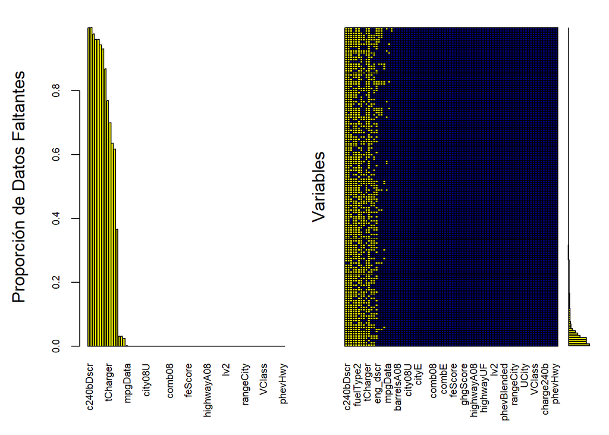

```
##
##  Variables sorted by number of missings:
##         Variable        Count
##        c240bDscr 9.972961e-01
##         c240Dscr 9.971759e-01
##         sCharger 9.770865e-01
##           rangeA 9.598414e-01
##        fuelType2 9.597813e-01
##          guzzler 9.431570e-01
##          evMotor 9.302982e-01
##          atvType 8.677669e-01
##         tCharger 7.682016e-01
##       trans_dscr 6.986801e-01
##        startStop 6.347067e-01
##          mfrCode 6.170609e-01
##         eng_dscr 3.654936e-01
##        cylinders 3.012398e-02
##            displ 3.008392e-02
##            drive 2.375468e-02
##          mpgData 1.622369e-03
##            trany 2.203217e-04
##        fuelType1 4.005849e-05
##        barrels08 0.000000e+00
##       barrelsA08 0.000000e+00
##        charge120 0.000000e+00
##        charge240 0.000000e+00
##           city08 0.000000e+00
##          city08U 0.000000e+00
##          cityA08 0.000000e+00
##         cityA08U 0.000000e+00
##           cityCD 0.000000e+00
##            cityE 0.000000e+00
##           cityUF 0.000000e+00
##              co2 0.000000e+00
##             co2A 0.000000e+00
##  co2TailpipeAGpm 0.000000e+00
##   co2TailpipeGpm 0.000000e+00
##           comb08 0.000000e+00
##          comb08U 0.000000e+00
##          combA08 0.000000e+00
```

[output cut: 32 more lines]

```
##        rangeHwyA 0.000000e+00
##            UCity 0.000000e+00
##           UCityA 0.000000e+00
##         UHighway 0.000000e+00
##        UHighwayA 0.000000e+00
##           VClass 0.000000e+00
##             year 0.000000e+00
##     youSaveSpend 0.000000e+00
##        baseModel 0.000000e+00
##       charge240b 0.000000e+00
##        createdOn 0.000000e+00
##       modifiedOn 0.000000e+00
##         phevCity 0.000000e+00
##          phevHwy 0.000000e+00
##         phevComb 0.000000e+00
```

```r
aggr(datos, col = c('navyblue', 'yellow'), numbers = TRUE, sortVars = TRUE, labels = names(datos), cex.axis = 0.7, gap = 3, ylab = c("Proporción de Datos Faltantes", "Variables"))
```

## 3.5 Identificador de Duplicados

### 3.5.1 verificamos si hay datos duplicados

```r
duplicated_rows <- datos[duplicated(datos), ]
nrow(duplicated_rows)
```

```
## [1] 0
```

### 3.5.2 Datos repetivos sin tener en cuenta el ID

Como no tenemos datos repetidos en nuestro dataset, verificamos si esto se debe a la variable ID o si confirmamos que en realidad no se tienen datos repetidos.

```r
datos_sin <-(datos[ , -1])
head(datos_sin)
```

```
## # A tibble: 6 × 83
##   barrelsA08 charge120 charge240 city08 city08U cityA08 cityA08U cityCD cityE
##        <dbl>     <dbl>     <dbl>  <dbl>   <dbl>   <dbl>    <dbl>  <dbl> <dbl>
## 1          0         0         0     19       0       0        0      0     0
## 2          0         0         0      9       0       0        0      0     0
## 3          0         0         0     23       0       0        0      0     0
## 4          0         0         0     10       0       0        0      0     0
## 5          0         0         0     17       0       0        0      0     0
## 6          0         0         0     21       0       0        0      0     0
## # ℹ 74 more variables: cityUF <dbl>, co2 <dbl>, co2A <dbl>,
## #   co2TailpipeAGpm <dbl>, co2TailpipeGpm <dbl>, comb08 <dbl>, comb08U <dbl>,
## #   combA08 <dbl>, combA08U <dbl>, combE <dbl>, combinedCD <dbl>,
## #   combinedUF <dbl>, cylinders <dbl>, displ <dbl>, drive <chr>, engId <dbl>,
## #   eng_dscr <chr>, feScore <dbl>, fuelCost08 <dbl>, fuelCostA08 <dbl>,
## #   fuelType <chr>, fuelType1 <chr>, ghgScore <dbl>, ghgScoreA <dbl>,
## #   highway08 <dbl>, highway08U <dbl>, highwayA08 <dbl>, highwayA08U <dbl>, …
```

**Averiguamos el número total de filas repetidas**

```r
sum(duplicated(datos))
```

```
## [1] 0
```

### 3.5.3 Eliminamos columnas con datos perdidos

Data sin datos perdidos, es decir, eliminamos columnas con los valores perdidos más altos y que no se relacionan directamente con las emisiones de CO2 y el tipo de transmisión del automovil, además, eliminamos las columnas con valores nulos.

```r
Columnas_a_eliminar <- c("c240bDscr", "c240Dscr", "sCharger", "rangeA", "guzzler", "atvType", "tCharger", "trans_dscr", "startStop", "mfrCode", "eng_dscr", "displ", "drive", "mpgData", "pv2", "pv4", "range", "rangeCity", "barrelsA08", "charge120", "charge240", "charge240b", "city08U", "cityA08", "cityA08U", "cityCD", "cityE", "cityUF", "co2TailpipeAGpm", "comb08U", "combA08", "combA08U", "combE", "combinedCD", "combinedUF", "fuelCostA08", "highway08U", "highwayA08", "highwayA08U", "highwayCD", "highwayE", "highwayUF", "lv2", "rangeCityA", "rangeHwy", "rangeHwyA", "UCityA", "UHighwayA", "phevCity",
"phevHwy", "phevComb" )

datos_limpios <- datos[, !(names(datos) %in% Columnas_a_eliminar)]


head(datos_limpios)
```

```
## # A tibble: 6 × 33
##   barrels08 city08   co2  co2A co2TailpipeGpm comb08 cylinders engId feScore
##       <dbl>  <dbl> <dbl> <dbl>          <dbl>  <dbl>     <dbl> <dbl>   <dbl>
## 1      14.2     19    -1    -1           423.     21         4  9011      -1
## 2      27.0      9    -1    -1           808.     11        12 22020      -1
## 3      11.0     23    -1    -1           329.     27         4  2100      -1
## 4      27.0     10    -1    -1           808.     11         8  2850      -1
## 5      15.7     17    -1    -1           468.     19         4 66031      -1
## 6      13.5     21    -1    -1           404.     22         4 66020      -1
## # ℹ 24 more variables: fuelCost08 <dbl>, fuelType <chr>, fuelType1 <chr>,
## #   ghgScore <dbl>, ghgScoreA <dbl>, highway08 <dbl>, hlv <dbl>, hpv <dbl>,
## #   id <dbl>, lv4 <dbl>, make <chr>, model <chr>, phevBlended <lgl>,
## #   trany <chr>, UCity <dbl>, UHighway <dbl>, VClass <chr>, year <dbl>,
## #   youSaveSpend <dbl>, baseModel <chr>, fuelType2 <chr>, evMotor <chr>,
## #   createdOn <chr>, modifiedOn <chr>
```

```r
dim(datos_limpios)
```

```
## [1] 49927    33
```

Vemos las columas con las que quedamos en nuestros datos

```r
colnames(datos_limpios)
```

```
##  [1] "barrels08"      "city08"         "co2"            "co2A"
##  [5] "co2TailpipeGpm" "comb08"         "cylinders"      "engId"
##  [9] "feScore"        "fuelCost08"     "fuelType"       "fuelType1"
## [13] "ghgScore"       "ghgScoreA"      "highway08"      "hlv"
## [17] "hpv"            "id"             "lv4"            "make"
## [21] "model"          "phevBlended"    "trany"          "UCity"
## [25] "UHighway"       "VClass"         "year"           "youSaveSpend"
## [29] "baseModel"      "fuelType2"      "evMotor"        "createdOn"
## [33] "modifiedOn"
```

> Después de llevar a cabo un proceso de limpieza de datos y eliminar columnas que no aportaban valor significativo al análisis, hemos reducido nuestro conjunto de datos a un total de 33 columnas clave. Estas columnas incluyen variables relevantes como “barrels08”, que puede indicar el consumo de combustible, y “co2”, que refleja las emisiones de dióxido de carbono. También se conservan columnas que proporcionan información sobre el tipo de combustible, el rendimiento del vehículo y las características del modelo, como “fuelType”, “hpv” y “year”. Esta selección de columnas es fundamental para realizar un análisis más enfocado y efectivo, ya que se centra en datos que son más propensos a influir en los resultados y en la toma de decisiones. La limpieza ha permitido eliminar el ruido de datos irrelevantes, mejorando así la calidad y la utilidad del conjunto de datos.

*NOTA:* NO SE ELIMINARON POR FILAS YA QUE AL REALIZARLO ME QUEDO SIN REGISTROS. ENTONCES SOLO QUITAMOS COLUMNAS QUE NO SE RELACIONAN CON NUESTRA VARIABLE OBJETIVO.